# Enrichment analysis with clusterProfiler

Rene Welch

February, 2018

# 1 Introduction

We are going to perform a pathway analysis, I am using the data from Figure 3, i.e. genes that were differentiallly expressed in specific EBV or NOKS cell lines after applying the MC treatment:

```
## [1] "alignment"       "diff_genes_EBV"  "diff_genes_NOKS" "fdr"
## [5] "rlogmat"         "rsem_data"
```

# 2 Preparing the data

## 2.1 Gene Ontology list V5.1

```
##                       all                        bp
## "c5.all.v5.1.symbols.gmt"  "c5.bp.v5.1.symbols.gmt"
##                        cc                        mf
##  "c5.cc.v5.1.symbols.gmt"  "c5.mf.v5.1.symbols.gmt"
```

There is one list of genes that contains all, and there are three separated subsets:

- **bp**: Biological processes
- **cc**: Cellular component
- **mf**: Molecular function

## 2.2 Keratinocytes pathways

First, we search for ontologies with `KERA` in the name, and notice that those gene list are only present in the biological processes. So, we are going to focus on that gene list.

```r
onto_keratinocyte = ontologies %>%
  map(filter,str_detect(ont,"KERA"))

onto_keratinocyte %>%
  map_int(nrow)
```

```
## all  bp  cc  mf
##  15  15   0   0
```

```r
onto_keratinocyte[["bp"]]
```

```
##                             ont   gene
## 1  KERATINOCYTE_DIFFERENTIATION    LOR
## 2  KERATINOCYTE_DIFFERENTIATION  TXNIP
## 3  KERATINOCYTE_DIFFERENTIATION  ANXA1
## 4  KERATINOCYTE_DIFFERENTIATION   SCEL
## 5  KERATINOCYTE_DIFFERENTIATION   IL20
## 6  KERATINOCYTE_DIFFERENTIATION   NME2
## 7  KERATINOCYTE_DIFFERENTIATION   EVPL
## 8  KERATINOCYTE_DIFFERENTIATION   EREG
## 9  KERATINOCYTE_DIFFERENTIATION SPRR1A
## 10 KERATINOCYTE_DIFFERENTIATION SPRR1B
## 11 KERATINOCYTE_DIFFERENTIATION   TGM1
## 12 KERATINOCYTE_DIFFERENTIATION   TGM3
## 13 KERATINOCYTE_DIFFERENTIATION    DSP
## 14 KERATINOCYTE_DIFFERENTIATION   CSTA
## 15 KERATINOCYTE_DIFFERENTIATION    IVL
```

## 2.3 Diff expressed genes

We define a gene to be diff. expressed if the adjusted p.value is $\leq 0.05$

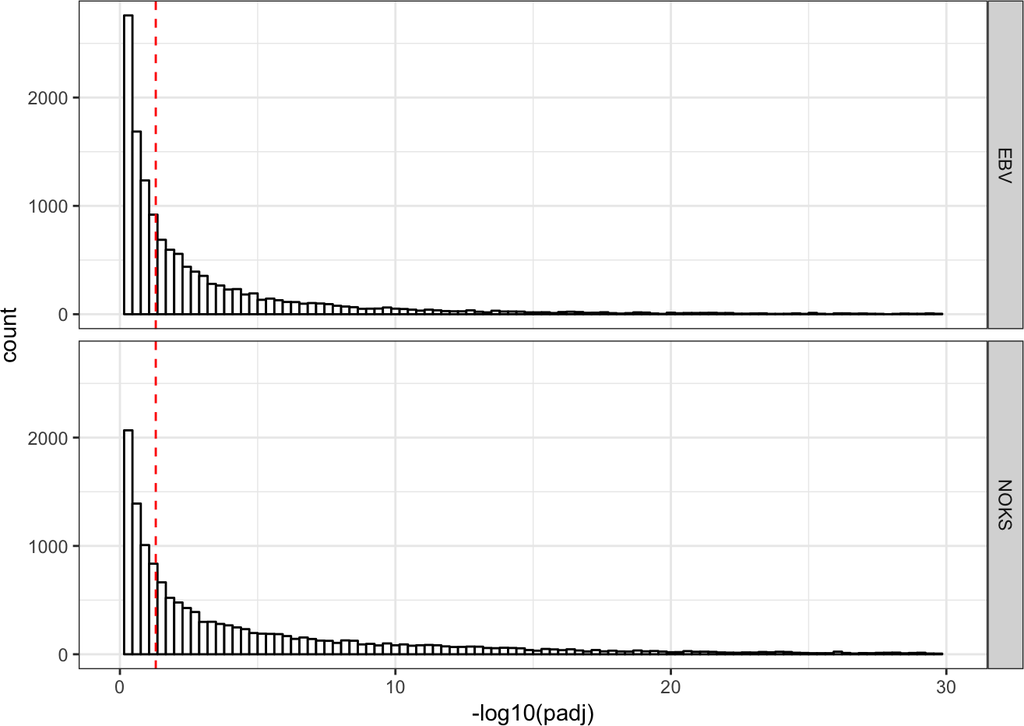

# 3 Pathway analysis on the Biological processes ontology

## 3.1 Quick summary

[output not shown]

## 3.2 GSEA analysis with pval_threshold = 0.1

**Quick note**: In the figures below, I truncated the gene sets names at 40 character to get better visualizations.

### 3.2.1 All genes

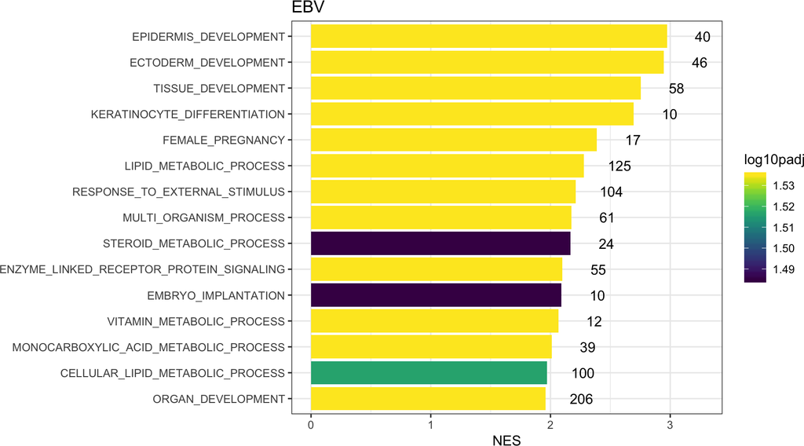

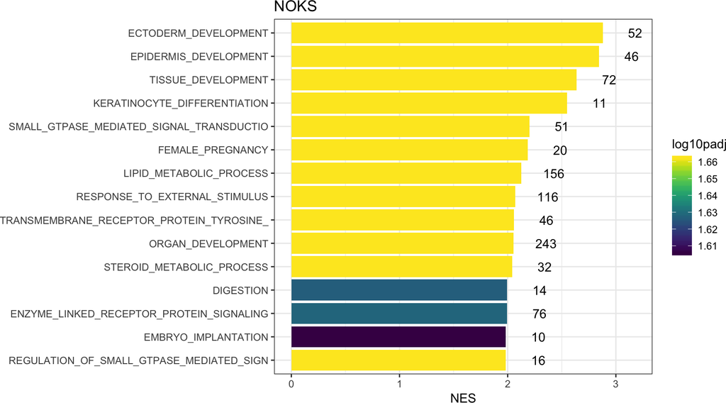

### 3.2.2 Upregulated

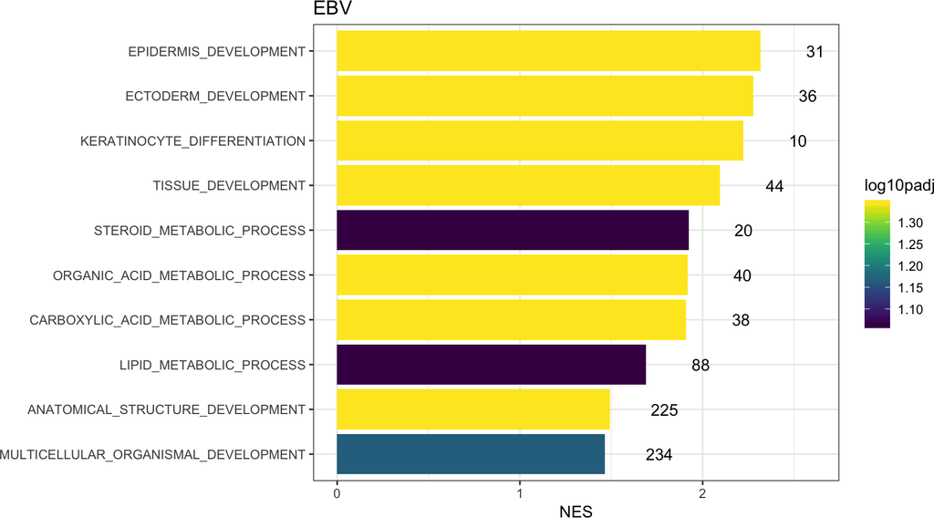

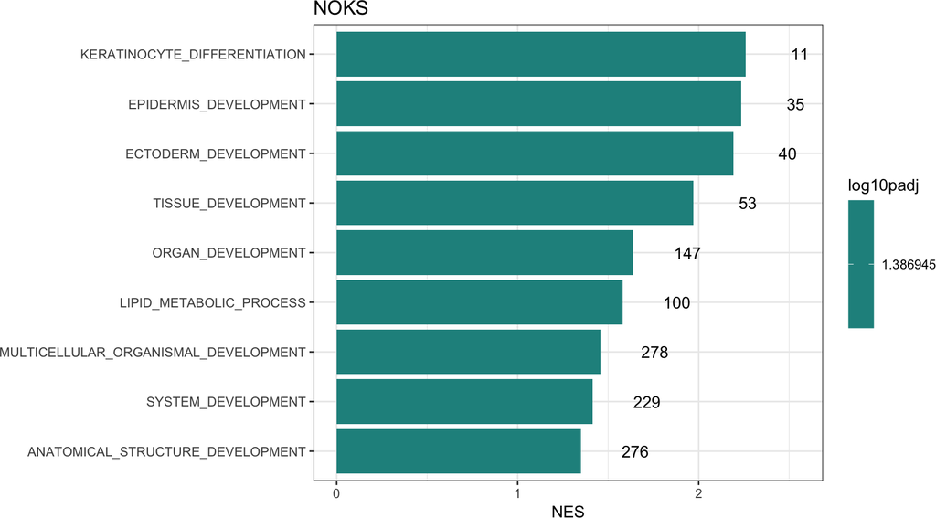

### 3.2.3 Downregulated

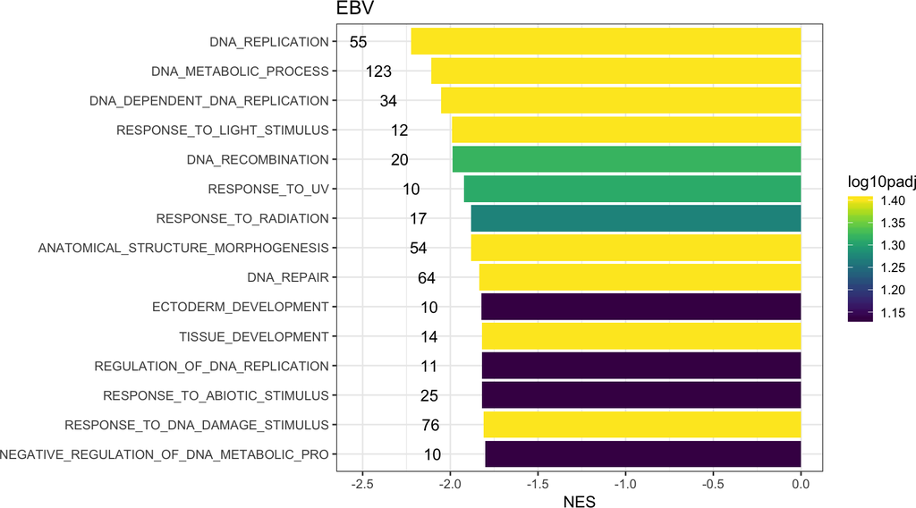

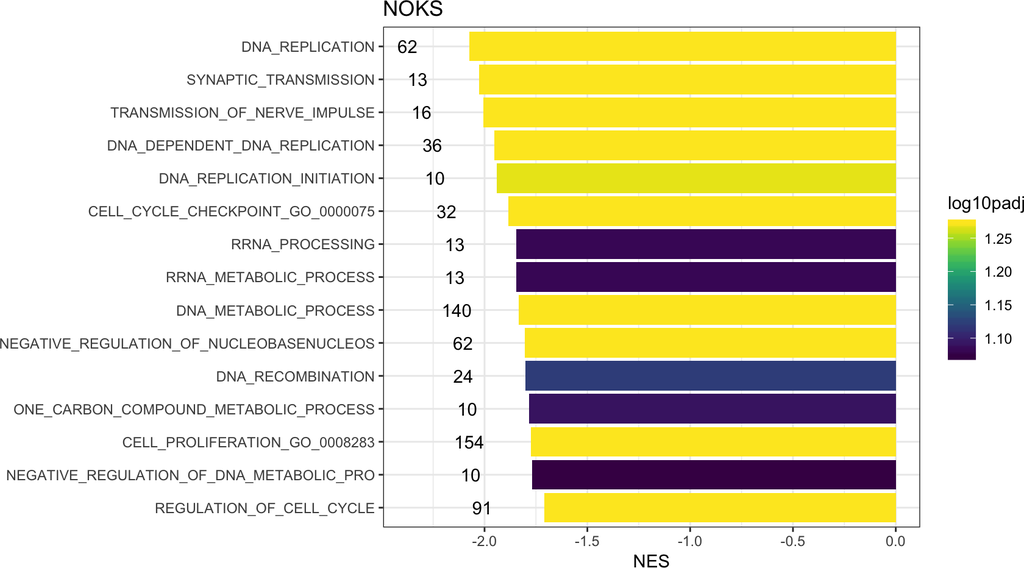

## 3.3 Extra analysis: Seached `kera` in MolSigDB

I constructed a gene list by searching in the GSEA website all the gene sets related to KERANOCYTES. We repeated the previous GSEA analysis:

```
## # A tibble: 6 x 4
##   cell  type    gsea_0.05 gsea_0.1
##   <chr> <chr>       <int>    <int>
## 1 EBV   all            11       15
## 2 NOKS  all            15       19
## 3 EBV   upreg           9       11
## 4 NOKS  upreg           9       12
## 5 EBV   downreg         1        1
## 6 NOKS  downreg         1        1
```

### 3.3.1 All genes

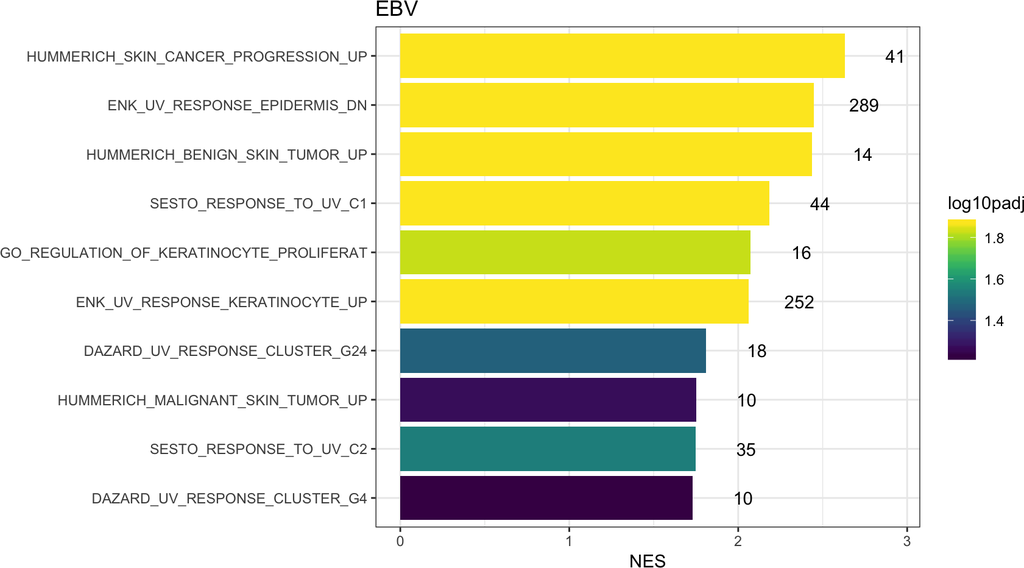

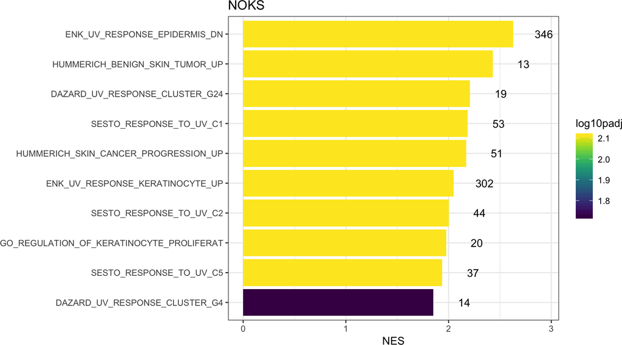

### 3.3.2 Upregulated

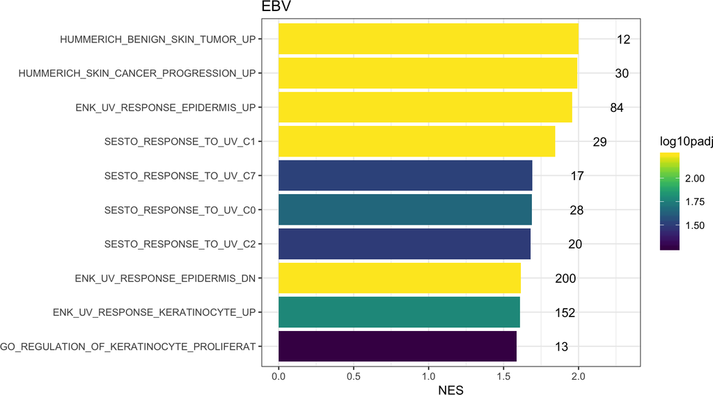

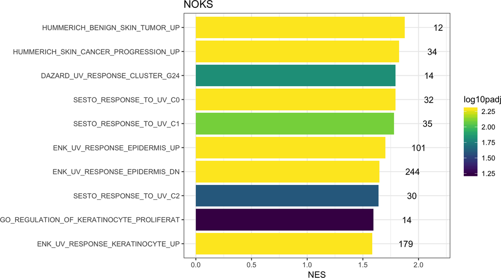

### 3.3.3 Downregulated

**Note**: Only the following, which can change due to the permuation:

```r
kera_results %>%
  filter(type == "downreg") %>%
  pluck("gsea_0.1")
```

```
## [[1]]
## # A tibble: 1 x 13
##   ID      Description setSize enrichmentScore   NES  pvalue p.adjust qvalues
##   <chr>   <chr>         <int>           <dbl> <dbl>   <dbl>    <dbl>   <dbl>
## 1 ENK_UV… ENK_UV_RES…     162          -0.307 -1.54 0.00200   0.0440  0.0400
## # ... with 5 more variables: rank <dbl>, leading_edge <chr>,
## #   core_enrichment <chr>, log10pval <dbl>, log10padj <dbl>
##
## [[2]]
## # A tibble: 1 x 13
##   ID      Description setSize enrichmentScore   NES  pvalue p.adjust qvalues
##   <chr>   <chr>         <int>           <dbl> <dbl>   <dbl>    <dbl>   <dbl>
## 1 ENK_UV… ENK_UV_RES…     199          -0.331 -1.54 9.99e⁻⁴   0.0240  0.0200
## # ... with 5 more variables: rank <dbl>, leading_edge <chr>,
## #   core_enrichment <chr>, log10pval <dbl>, log10padj <dbl>
```

# 4 Bibliography

G Yu, LG Wang, Y Han, QY He. clusterProfiler: an R package for comparing biological themes among gene clusters. OMICS: A Journal of Integrative Biology 2012, 16(5):284-287. doi:[10.1089/omi.2011.0118](http://dx.doi.org/10.1089/omi.2011.0118)